# Risk Factor Analysis

## Outcome Variable

**Outcome Variable:** wast_rec90d

## Predictor Variables

**Intervention Variable:** parity

**Adjustment Set:**

- arm
- W_mage
- meducyrs
- feducyrs
- hhwealth_quart
- W_mhtcm
- W_mwtkg
- W_mbmi
- vagbrth
- W_nrooms
- impsan
- delta_W_mage
- delta_meducyrs
- delta_feducyrs
- delta_hhwealth_quart
- delta_W_mhtcm
- delta_W_mwtkg
- delta_W_mbmi
- delta_vagbrth
- delta_W_nrooms
- delta_impsan

## Stratifying Variables

The analysis was stratified on these variable(s):

- agecat
- studyid
- country

## Data Summary

| agecat | studyid | country | parity | wast_rec90d | n_cell | n |
| --- | --- | --- | --- | --- | --- | --- |
| 0-24 months | COHORTS | GUATEMALA | 1 | 0 | 26 | 380 |
| 0-24 months | COHORTS | GUATEMALA | 1 | 1 | 23 | 380 |
| 0-24 months | COHORTS | GUATEMALA | 2 | 0 | 27 | 380 |
| 0-24 months | COHORTS | GUATEMALA | 2 | 1 | 32 | 380 |
| 0-24 months | COHORTS | GUATEMALA | 3+ | 0 | 159 | 380 |
| 0-24 months | COHORTS | GUATEMALA | 3+ | 1 | 113 | 380 |
| 0-24 months | COHORTS | INDIA | 1 | 0 | 188 | 1708 |
| 0-24 months | COHORTS | INDIA | 1 | 1 | 82 | 1708 |
| 0-24 months | COHORTS | INDIA | 2 | 0 | 296 | 1708 |
| 0-24 months | COHORTS | INDIA | 2 | 1 | 98 | 1708 |
| 0-24 months | COHORTS | INDIA | 3+ | 0 | 830 | 1708 |
| 0-24 months | COHORTS | INDIA | 3+ | 1 | 214 | 1708 |
| 0-24 months | COHORTS | PHILIPPINES | 1 | 0 | 140 | 1689 |
| 0-24 months | COHORTS | PHILIPPINES | 1 | 1 | 241 | 1689 |
| 0-24 months | COHORTS | PHILIPPINES | 2 | 0 | 133 | 1689 |
| 0-24 months | COHORTS | PHILIPPINES | 2 | 1 | 226 | 1689 |
| 0-24 months | COHORTS | PHILIPPINES | 3+ | 0 | 391 | 1689 |
| 0-24 months | COHORTS | PHILIPPINES | 3+ | 1 | 558 | 1689 |
| 0-24 months | GMS-Nepal | NEPAL | 1 | 0 | 79 | 643 |
| 0-24 months | GMS-Nepal | NEPAL | 1 | 1 | 101 | 643 |
| 0-24 months | GMS-Nepal | NEPAL | 2 | 0 | 72 | 643 |
| 0-24 months | GMS-Nepal | NEPAL | 2 | 1 | 86 | 643 |
| 0-24 months | GMS-Nepal | NEPAL | 3+ | 0 | 145 | 643 |
| 0-24 months | GMS-Nepal | NEPAL | 3+ | 1 | 160 | 643 |
| 0-24 months | JiVitA-3 | BANGLADESH | 1 | 0 | 1654 | 7571 |
| 0-24 months | JiVitA-3 | BANGLADESH | 1 | 1 | 1306 | 7571 |
| 0-24 months | JiVitA-3 | BANGLADESH | 2 | 0 | 1354 | 7571 |
| 0-24 months | JiVitA-3 | BANGLADESH | 2 | 1 | 986 | 7571 |
| 0-24 months | JiVitA-3 | BANGLADESH | 3+ | 0 | 1367 | 7571 |
| 0-24 months | JiVitA-3 | BANGLADESH | 3+ | 1 | 904 | 7571 |

[output cut: 168 more lines]

The following strata were considered:

- agecat: 0-24 months, studyid: COHORTS, country: GUATEMALA
- agecat: 0-24 months, studyid: COHORTS, country: INDIA
- agecat: 0-24 months, studyid: COHORTS, country: PHILIPPINES
- agecat: 0-24 months, studyid: GMS-Nepal, country: NEPAL
- agecat: 0-24 months, studyid: JiVitA-3, country: BANGLADESH
- agecat: 0-24 months, studyid: Keneba, country: GAMBIA
- agecat: 0-24 months, studyid: PROVIDE, country: BANGLADESH
- agecat: 0-24 months, studyid: SAS-CompFeed, country: INDIA
- agecat: 0-24 months, studyid: SAS-FoodSuppl, country: INDIA
- agecat: 0-24 months, studyid: TanzaniaChild2, country: TANZANIA, UNITED REPUBLIC OF
- agecat: 0-24 months, studyid: ZVITAMBO, country: ZIMBABWE
- agecat: 0-6 months, studyid: COHORTS, country: GUATEMALA
- agecat: 0-6 months, studyid: COHORTS, country: INDIA
- agecat: 0-6 months, studyid: COHORTS, country: PHILIPPINES
- agecat: 0-6 months, studyid: GMS-Nepal, country: NEPAL
- agecat: 0-6 months, studyid: JiVitA-3, country: BANGLADESH
- agecat: 0-6 months, studyid: Keneba, country: GAMBIA
- agecat: 0-6 months, studyid: PROVIDE, country: BANGLADESH
- agecat: 0-6 months, studyid: SAS-CompFeed, country: INDIA
- agecat: 0-6 months, studyid: SAS-FoodSuppl, country: INDIA
- agecat: 0-6 months, studyid: TanzaniaChild2, country: TANZANIA, UNITED REPUBLIC OF
- agecat: 0-6 months, studyid: ZVITAMBO, country: ZIMBABWE
- agecat: 6-24 months, studyid: COHORTS, country: GUATEMALA
- agecat: 6-24 months, studyid: COHORTS, country: INDIA
- agecat: 6-24 months, studyid: COHORTS, country: PHILIPPINES
- agecat: 6-24 months, studyid: GMS-Nepal, country: NEPAL
- agecat: 6-24 months, studyid: JiVitA-3, country: BANGLADESH
- agecat: 6-24 months, studyid: Keneba, country: GAMBIA
- agecat: 6-24 months, studyid: PROVIDE, country: BANGLADESH
- agecat: 6-24 months, studyid: SAS-CompFeed, country: INDIA
- agecat: 6-24 months, studyid: SAS-FoodSuppl, country: INDIA
- agecat: 6-24 months, studyid: TanzaniaChild2, country: TANZANIA, UNITED REPUBLIC OF
- agecat: 6-24 months, studyid: ZVITAMBO, country: ZIMBABWE

### Dropped Strata

Some strata were dropped due to rare outcomes:

- agecat: 0-24 months, studyid: SAS-FoodSuppl, country: INDIA
- agecat: 0-6 months, studyid: SAS-FoodSuppl, country: INDIA
- agecat: 6-24 months, studyid: COHORTS, country: GUATEMALA
- agecat: 6-24 months, studyid: COHORTS, country: INDIA
- agecat: 6-24 months, studyid: JiVitA-3, country: BANGLADESH
- agecat: 6-24 months, studyid: SAS-FoodSuppl, country: INDIA

## Methods Detail

We’re interested in the causal parameters $E[Y_a]$ for all values of $a \in \mathcal{A}$. These parameters represent the mean outcome if, possibly contrary to fact, we intervened to set all units to have $A=a$. Under the randomization and positivity assumptions, these are identified by the statistical parameters $\psi_a=E_W[E_{Y|A,W}(Y|A=a,W)]$. In addition, we’re interested in the mean of $Y$, $E[Y]$ under no intervention (the observed mean). We will estimate these parameters by using SuperLearner to fit the relevant likelihood factors – $E_{Y|A,W}(Y|A=a,W)$ and $p(A=a|W)$, and then updating our likelihood fit using a joint TMLE.

For unadjusted analyses ($W=\{\}$), initial likelihoods were estimated using Lrnr_glm to estimate the simple $E(Y|A)$ and Lrnr_mean to estimate $p(A)$. For adjusted analyses, a small library containing Lrnr_glmnet, Lrnr_xgboost, and Lrnr_mean was used.

Having estimated these parameters, we will then use the delta method to estimate relative risks and attributable risks relative to a prespecified baseline level of $A$.

# Results Detail

## Results Plots

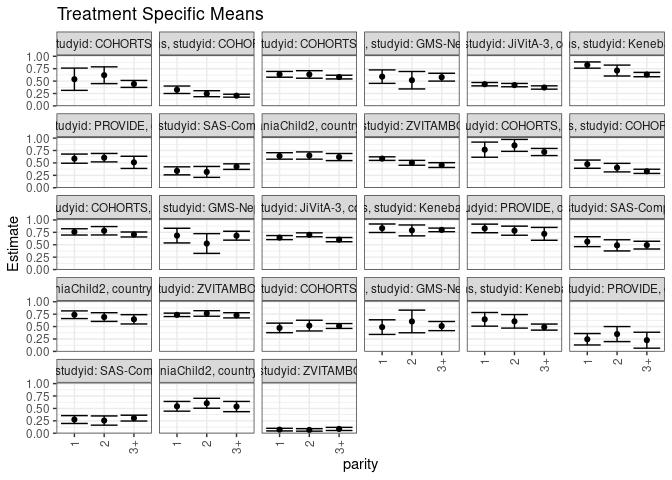

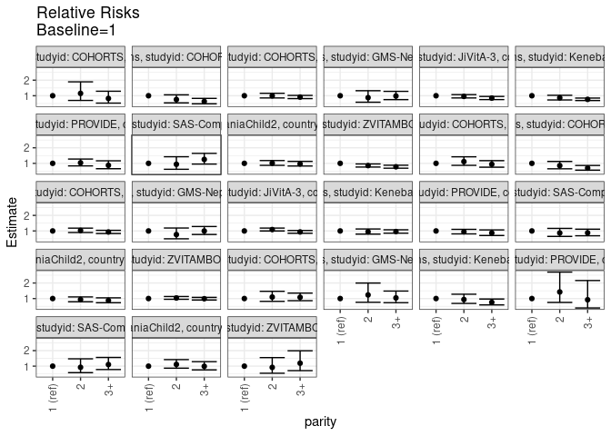

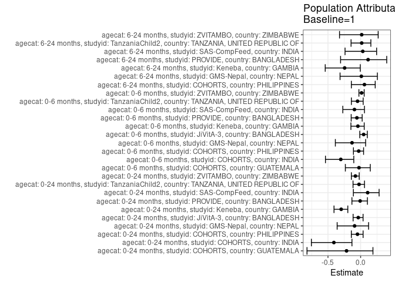

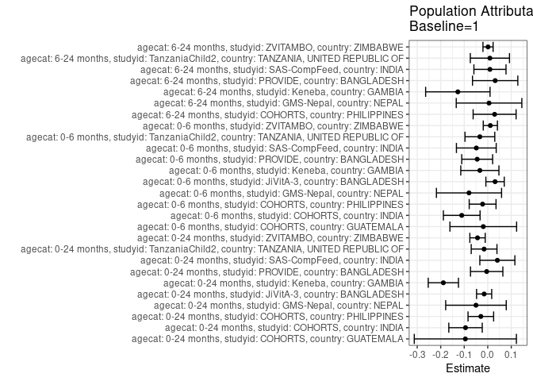

## Results Table

### Parameter: TSM

| agecat | studyid | country | intervention_level | baseline_level | estimate | ci_lower | ci_upper |
| --- | --- | --- | --- | --- | --- | --- | --- |
| 0-24 months | COHORTS | GUATEMALA | 1 | NA | 0.5374104 | 0.3131661 | 0.7616547 |
| 0-24 months | COHORTS | GUATEMALA | 2 | NA | 0.6183059 | 0.4495205 | 0.7870914 |
| 0-24 months | COHORTS | GUATEMALA | 3+ | NA | 0.4431801 | 0.3728208 | 0.5135393 |
| 0-24 months | COHORTS | INDIA | 1 | NA | 0.3251678 | 0.2500212 | 0.4003143 |
| 0-24 months | COHORTS | INDIA | 2 | NA | 0.2457668 | 0.1856342 | 0.3058993 |
| 0-24 months | COHORTS | INDIA | 3+ | NA | 0.2055861 | 0.1758511 | 0.2353211 |
| 0-24 months | COHORTS | PHILIPPINES | 1 | NA | 0.6362672 | 0.5783562 | 0.6941783 |
| 0-24 months | COHORTS | PHILIPPINES | 2 | NA | 0.6337866 | 0.5582239 | 0.7093493 |
| 0-24 months | COHORTS | PHILIPPINES | 3+ | NA | 0.5805929 | 0.5433745 | 0.6178113 |
| 0-24 months | GMS-Nepal | NEPAL | 1 | NA | 0.5897141 | 0.4542364 | 0.7251919 |
| 0-24 months | GMS-Nepal | NEPAL | 2 | NA | 0.5175224 | 0.3417158 | 0.6933290 |
| 0-24 months | GMS-Nepal | NEPAL | 3+ | NA | 0.5784223 | 0.4993160 | 0.6575286 |
| 0-24 months | JiVitA-3 | BANGLADESH | 1 | NA | 0.4374362 | 0.4035296 | 0.4713428 |
| 0-24 months | JiVitA-3 | BANGLADESH | 2 | NA | 0.4191941 | 0.3856304 | 0.4527577 |
| 0-24 months | JiVitA-3 | BANGLADESH | 3+ | NA | 0.3710123 | 0.3372396 | 0.4047850 |
| 0-24 months | Keneba | GAMBIA | 1 | NA | 0.8230285 | 0.7602307 | 0.8858264 |
| 0-24 months | Keneba | GAMBIA | 2 | NA | 0.7123467 | 0.6026125 | 0.8220809 |
| 0-24 months | Keneba | GAMBIA | 3+ | NA | 0.6313430 | 0.5877937 | 0.6748924 |
| 0-24 months | PROVIDE | BANGLADESH | 1 | NA | 0.5857231 | 0.4932640 | 0.6781822 |
| 0-24 months | PROVIDE | BANGLADESH | 2 | NA | 0.6051440 | 0.5200163 | 0.6902717 |
| 0-24 months | PROVIDE | BANGLADESH | 3+ | NA | 0.5113612 | 0.3889424 | 0.6337800 |
| 0-24 months | SAS-CompFeed | INDIA | 1 | NA | 0.3399527 | 0.2591188 | 0.4207867 |
| 0-24 months | SAS-CompFeed | INDIA | 2 | NA | 0.3188810 | 0.2093217 | 0.4284403 |
| 0-24 months | SAS-CompFeed | INDIA | 3+ | NA | 0.4252980 | 0.3692042 | 0.4813918 |
| 0-24 months | TanzaniaChild2 | TANZANIA, UNITED REPUBLIC OF | 1 | NA | 0.6409009 | 0.5759667 | 0.7058350 |
| 0-24 months | TanzaniaChild2 | TANZANIA, UNITED REPUBLIC OF | 2 | NA | 0.6488944 | 0.5756147 | 0.7221741 |
| 0-24 months | TanzaniaChild2 | TANZANIA, UNITED REPUBLIC OF | 3+ | NA | 0.6183084 | 0.5465850 | 0.6900318 |
| 0-24 months | ZVITAMBO | ZIMBABWE | 1 | NA | 0.5867483 | 0.5505060 | 0.6229906 |
| 0-24 months | ZVITAMBO | ZIMBABWE | 2 | NA | 0.5022412 | 0.4532922 | 0.5511903 |
| 0-24 months | ZVITAMBO | ZIMBABWE | 3+ | NA | 0.4564992 | 0.4081708 | 0.5048276 |

[output cut: 51 more lines]

### Parameter: E(Y)

| agecat | studyid | country | intervention_level | baseline_level | estimate | ci_lower | ci_upper |
| --- | --- | --- | --- | --- | --- | --- | --- |
| 0-24 months | COHORTS | GUATEMALA | NA | NA | 0.4421053 | 0.3904403 | 0.4937702 |
| 0-24 months | COHORTS | INDIA | NA | NA | 0.2306792 | 0.2105836 | 0.2507747 |
| 0-24 months | COHORTS | PHILIPPINES | NA | NA | 0.6068680 | 0.5823645 | 0.6313715 |
| 0-24 months | GMS-Nepal | NEPAL | NA | NA | 0.5396579 | 0.4973524 | 0.5819633 |
| 0-24 months | JiVitA-3 | BANGLADESH | NA | NA | 0.4221371 | 0.4110175 | 0.4332567 |
| 0-24 months | Keneba | GAMBIA | NA | NA | 0.6342142 | 0.6073589 | 0.6610695 |
| 0-24 months | PROVIDE | BANGLADESH | NA | NA | 0.5811688 | 0.5245443 | 0.6377934 |
| 0-24 months | SAS-CompFeed | INDIA | NA | NA | 0.3808354 | 0.3457640 | 0.4159068 |
| 0-24 months | TanzaniaChild2 | TANZANIA, UNITED REPUBLIC OF | NA | NA | 0.6253561 | 0.5873792 | 0.6633330 |
| 0-24 months | ZVITAMBO | ZIMBABWE | NA | NA | 0.5432918 | 0.5268968 | 0.5596869 |
| 0-6 months | COHORTS | GUATEMALA | NA | NA | 0.7476636 | 0.6894668 | 0.8058603 |
| 0-6 months | COHORTS | INDIA | NA | NA | 0.3641405 | 0.3354558 | 0.3928252 |
| 0-6 months | COHORTS | PHILIPPINES | NA | NA | 0.7367021 | 0.7051294 | 0.7682749 |
| 0-6 months | GMS-Nepal | NEPAL | NA | NA | 0.6045627 | 0.5449300 | 0.6641955 |
| 0-6 months | JiVitA-3 | BANGLADESH | NA | NA | 0.6751162 | 0.6617750 | 0.6884574 |
| 0-6 months | Keneba | GAMBIA | NA | NA | 0.7989865 | 0.7673199 | 0.8306531 |
| 0-6 months | PROVIDE | BANGLADESH | NA | NA | 0.7837838 | 0.7252863 | 0.8422812 |
| 0-6 months | SAS-CompFeed | INDIA | NA | NA | 0.5131965 | 0.4596632 | 0.5667297 |
| 0-6 months | TanzaniaChild2 | TANZANIA, UNITED REPUBLIC OF | NA | NA | 0.7053571 | 0.6558827 | 0.7548316 |
| 0-6 months | ZVITAMBO | ZIMBABWE | NA | NA | 0.7475189 | 0.7305656 | 0.7644721 |
| 6-24 months | COHORTS | PHILIPPINES | NA | NA | 0.5026681 | 0.4688378 | 0.5364984 |
| 6-24 months | GMS-Nepal | NEPAL | NA | NA | 0.4947368 | 0.4401559 | 0.5493178 |
| 6-24 months | Keneba | GAMBIA | NA | NA | 0.5189125 | 0.4826376 | 0.5551875 |
| 6-24 months | PROVIDE | BANGLADESH | NA | NA | 0.2764228 | 0.1950773 | 0.3577682 |
| 6-24 months | SAS-CompFeed | INDIA | NA | NA | 0.2854123 | 0.2436284 | 0.3271961 |
| 6-24 months | TanzaniaChild2 | TANZANIA, UNITED REPUBLIC OF | NA | NA | 0.5519126 | 0.4992021 | 0.6046230 |
| 6-24 months | ZVITAMBO | ZIMBABWE | NA | NA | 0.0739051 | 0.0584895 | 0.0893208 |

### Parameter: RR

| agecat | studyid | country | intervention_level | baseline_level | estimate | ci_lower | ci_upper |
| --- | --- | --- | --- | --- | --- | --- | --- |
| 0-24 months | COHORTS | GUATEMALA | 1 | 1 | 1.0000000 | 1.0000000 | 1.0000000 |
| 0-24 months | COHORTS | GUATEMALA | 2 | 1 | 1.1505284 | 0.6988137 | 1.8942324 |
| 0-24 months | COHORTS | GUATEMALA | 3+ | 1 | 0.8246585 | 0.5272903 | 1.2897291 |
| 0-24 months | COHORTS | INDIA | 1 | 1 | 1.0000000 | 1.0000000 | 1.0000000 |
| 0-24 months | COHORTS | INDIA | 2 | 1 | 0.7558153 | 0.5399230 | 1.0580337 |
| 0-24 months | COHORTS | INDIA | 3+ | 1 | 0.6322463 | 0.4814648 | 0.8302485 |
| 0-24 months | COHORTS | PHILIPPINES | 1 | 1 | 1.0000000 | 1.0000000 | 1.0000000 |
| 0-24 months | COHORTS | PHILIPPINES | 2 | 1 | 0.9961013 | 0.8575111 | 1.1570902 |
| 0-24 months | COHORTS | PHILIPPINES | 3+ | 1 | 0.9124985 | 0.8164808 | 1.0198077 |
| 0-24 months | GMS-Nepal | NEPAL | 1 | 1 | 1.0000000 | 1.0000000 | 1.0000000 |
| 0-24 months | GMS-Nepal | NEPAL | 2 | 1 | 0.8775818 | 0.5823601 | 1.3224633 |
| 0-24 months | GMS-Nepal | NEPAL | 3+ | 1 | 0.9808520 | 0.7505961 | 1.2817422 |
| 0-24 months | JiVitA-3 | BANGLADESH | 1 | 1 | 1.0000000 | 1.0000000 | 1.0000000 |
| 0-24 months | JiVitA-3 | BANGLADESH | 2 | 1 | 0.9582976 | 0.8572432 | 1.0712646 |
| 0-24 months | JiVitA-3 | BANGLADESH | 3+ | 1 | 0.8481518 | 0.7525854 | 0.9558537 |
| 0-24 months | Keneba | GAMBIA | 1 | 1 | 1.0000000 | 1.0000000 | 1.0000000 |
| 0-24 months | Keneba | GAMBIA | 2 | 1 | 0.8655188 | 0.7287681 | 1.0279303 |
| 0-24 months | Keneba | GAMBIA | 3+ | 1 | 0.7670974 | 0.6920267 | 0.8503116 |
| 0-24 months | PROVIDE | BANGLADESH | 1 | 1 | 1.0000000 | 1.0000000 | 1.0000000 |
| 0-24 months | PROVIDE | BANGLADESH | 2 | 1 | 1.0331571 | 0.8364381 | 1.2761418 |
| 0-24 months | PROVIDE | BANGLADESH | 3+ | 1 | 0.8730425 | 0.6549826 | 1.1637000 |
| 0-24 months | SAS-CompFeed | INDIA | 1 | 1 | 1.0000000 | 1.0000000 | 1.0000000 |
| 0-24 months | SAS-CompFeed | INDIA | 2 | 1 | 0.9380156 | 0.6177757 | 1.4242602 |
| 0-24 months | SAS-CompFeed | INDIA | 3+ | 1 | 1.2510503 | 0.9535170 | 1.6414251 |
| 0-24 months | TanzaniaChild2 | TANZANIA, UNITED REPUBLIC OF | 1 | 1 | 1.0000000 | 1.0000000 | 1.0000000 |
| 0-24 months | TanzaniaChild2 | TANZANIA, UNITED REPUBLIC OF | 2 | 1 | 1.0124723 | 0.8696875 | 1.1786994 |
| 0-24 months | TanzaniaChild2 | TANZANIA, UNITED REPUBLIC OF | 3+ | 1 | 0.9647489 | 0.8270085 | 1.1254303 |
| 0-24 months | ZVITAMBO | ZIMBABWE | 1 | 1 | 1.0000000 | 1.0000000 | 1.0000000 |
| 0-24 months | ZVITAMBO | ZIMBABWE | 2 | 1 | 0.8559739 | 0.7630927 | 0.9601604 |
| 0-24 months | ZVITAMBO | ZIMBABWE | 3+ | 1 | 0.7780154 | 0.6886548 | 0.8789714 |

[output cut: 51 more lines]

### Parameter: PAR

| agecat | studyid | country | intervention_level | baseline_level | estimate | ci_lower | ci_upper |
| --- | --- | --- | --- | --- | --- | --- | --- |
| 0-24 months | COHORTS | GUATEMALA | 1 | NA | -0.0953052 | -0.3124479 | 0.1218376 |
| 0-24 months | COHORTS | INDIA | 1 | NA | -0.0944886 | -0.1656118 | -0.0233655 |
| 0-24 months | COHORTS | PHILIPPINES | 1 | NA | -0.0293993 | -0.0838242 | 0.0250256 |
| 0-24 months | GMS-Nepal | NEPAL | 1 | NA | -0.0500563 | -0.1788430 | 0.0787304 |
| 0-24 months | JiVitA-3 | BANGLADESH | 1 | NA | -0.0152991 | -0.0474918 | 0.0168936 |
| 0-24 months | Keneba | GAMBIA | 1 | NA | -0.1888144 | -0.2531349 | -0.1244938 |
| 0-24 months | PROVIDE | BANGLADESH | 1 | NA | -0.0045543 | -0.0733717 | 0.0642631 |
| 0-24 months | SAS-CompFeed | INDIA | 1 | NA | 0.0408826 | -0.0336361 | 0.1154014 |
| 0-24 months | TanzaniaChild2 | TANZANIA, UNITED REPUBLIC OF | 1 | NA | -0.0155447 | -0.0703070 | 0.0392175 |
| 0-24 months | ZVITAMBO | ZIMBABWE | 1 | NA | -0.0434564 | -0.0761207 | -0.0107922 |
| 0-6 months | COHORTS | GUATEMALA | 1 | NA | -0.0190031 | -0.1607938 | 0.1227875 |
| 0-6 months | COHORTS | INDIA | 1 | NA | -0.1106453 | -0.1886425 | -0.0326481 |
| 0-6 months | COHORTS | PHILIPPINES | 1 | NA | -0.0217935 | -0.0788095 | 0.0352224 |
| 0-6 months | GMS-Nepal | NEPAL | 1 | NA | -0.0797180 | -0.2182544 | 0.0588184 |
| 0-6 months | JiVitA-3 | BANGLADESH | 1 | NA | 0.0311518 | -0.0079356 | 0.0702392 |
| 0-6 months | Keneba | GAMBIA | 1 | NA | -0.0335723 | -0.1146972 | 0.0475525 |
| 0-6 months | PROVIDE | BANGLADESH | 1 | NA | -0.0448513 | -0.1105386 | 0.0208359 |
| 0-6 months | SAS-CompFeed | INDIA | 1 | NA | -0.0485992 | -0.1332034 | 0.0360051 |
| 0-6 months | TanzaniaChild2 | TANZANIA, UNITED REPUBLIC OF | 1 | NA | -0.0334612 | -0.0968161 | 0.0298938 |
| 0-6 months | ZVITAMBO | ZIMBABWE | 1 | NA | 0.0110195 | -0.0190897 | 0.0411286 |
| 6-24 months | COHORTS | PHILIPPINES | 1 | NA | 0.0292241 | -0.0621391 | 0.1205874 |
| 6-24 months | GMS-Nepal | NEPAL | 1 | NA | 0.0054831 | -0.1339952 | 0.1449614 |
| 6-24 months | Keneba | GAMBIA | 1 | NA | -0.1271881 | -0.2641645 | 0.0097884 |
| 6-24 months | PROVIDE | BANGLADESH | 1 | NA | 0.0315248 | -0.0648316 | 0.1278812 |
| 6-24 months | SAS-CompFeed | INDIA | 1 | NA | 0.0093869 | -0.0589054 | 0.0776792 |
| 6-24 months | TanzaniaChild2 | TANZANIA, UNITED REPUBLIC OF | 1 | NA | 0.0091538 | -0.0741785 | 0.0924861 |
| 6-24 months | ZVITAMBO | ZIMBABWE | 1 | NA | 0.0012089 | -0.0203518 | 0.0227696 |

### Parameter: PAF

| agecat | studyid | country | intervention_level | baseline_level | estimate | ci_lower | ci_upper |
| --- | --- | --- | --- | --- | --- | --- | --- |
| 0-24 months | COHORTS | GUATEMALA | 1 | NA | -0.2155712 | -0.8209707 | 0.1885573 |
| 0-24 months | COHORTS | INDIA | 1 | NA | -0.4096106 | -0.7539499 | -0.1328727 |
| 0-24 months | COHORTS | PHILIPPINES | 1 | NA | -0.0484443 | -0.1422631 | 0.0376688 |
| 0-24 months | GMS-Nepal | NEPAL | 1 | NA | -0.0927556 | -0.3596202 | 0.1217291 |
| 0-24 months | JiVitA-3 | BANGLADESH | 1 | NA | -0.0362420 | -0.1154008 | 0.0372989 |
| 0-24 months | Keneba | GAMBIA | 1 | NA | -0.2977139 | -0.4075762 | -0.1964264 |
| 0-24 months | PROVIDE | BANGLADESH | 1 | NA | -0.0078364 | -0.1334212 | 0.1038334 |
| 0-24 months | SAS-CompFeed | INDIA | 1 | NA | 0.1073499 | -0.1111492 | 0.2828828 |
| 0-24 months | TanzaniaChild2 | TANZANIA, UNITED REPUBLIC OF | 1 | NA | -0.0248574 | -0.1163801 | 0.0591621 |
| 0-24 months | ZVITAMBO | ZIMBABWE | 1 | NA | -0.0799873 | -0.1419194 | -0.0214141 |
| 0-6 months | COHORTS | GUATEMALA | 1 | NA | -0.0254167 | -0.2337815 | 0.1477589 |
| 0-6 months | COHORTS | INDIA | 1 | NA | -0.3038534 | -0.5386325 | -0.1048991 |
| 0-6 months | COHORTS | PHILIPPINES | 1 | NA | -0.0295826 | -0.1100684 | 0.0450676 |
| 0-6 months | GMS-Nepal | NEPAL | 1 | NA | -0.1318606 | -0.3871751 | 0.0764624 |
| 0-6 months | JiVitA-3 | BANGLADESH | 1 | NA | 0.0461429 | -0.0135510 | 0.1023211 |
| 0-6 months | Keneba | GAMBIA | 1 | NA | -0.0420187 | -0.1487792 | 0.0548202 |
| 0-6 months | PROVIDE | BANGLADESH | 1 | NA | -0.0572241 | -0.1447136 | 0.0235786 |
| 0-6 months | SAS-CompFeed | INDIA | 1 | NA | -0.0946989 | -0.2730125 | 0.0586378 |
| 0-6 months | TanzaniaChild2 | TANZANIA, UNITED REPUBLIC OF | 1 | NA | -0.0474386 | -0.1415556 | 0.0389187 |
| 0-6 months | ZVITAMBO | ZIMBABWE | 1 | NA | 0.0147414 | -0.0263743 | 0.0542100 |
| 6-24 months | COHORTS | PHILIPPINES | 1 | NA | 0.0581380 | -0.1421596 | 0.2233100 |
| 6-24 months | GMS-Nepal | NEPAL | 1 | NA | 0.0110829 | -0.3150634 | 0.2563423 |
| 6-24 months | Keneba | GAMBIA | 1 | NA | -0.2451050 | -0.5421099 | -0.0053022 |
| 6-24 months | PROVIDE | BANGLADESH | 1 | NA | 0.1140456 | -0.3070302 | 0.3994667 |
| 6-24 months | SAS-CompFeed | INDIA | 1 | NA | 0.0328889 | -0.2384900 | 0.2448030 |
| 6-24 months | TanzaniaChild2 | TANZANIA, UNITED REPUBLIC OF | 1 | NA | 0.0165856 | -0.1465966 | 0.1565438 |
| 6-24 months | ZVITAMBO | ZIMBABWE | 1 | NA | 0.0163574 | -0.3232310 | 0.2687952 |